# Prueba Practica Números Pseudo-aleatorios.

Elavorado por: Rotman Zurita

1. A traves de la misma api generar una semilla diferente.
2. Encontrar el numero de iteraciones hasta que se repita uno de sus datos.
3. Generar 100 simulaciones con diferentes semillas.

## Método de cuadrados Medios

```python
import numpy as np

semilla = input("Semilla:  ")
digitos = int((input("Numero de Digitos:  "))) #Recomencadion mayor 3
rango = int((input("Ingrese la cantidad de numeros pseudoaleatorios:  ")))

tamanio = len(semilla)
numS = int(semilla)
numero = '1'
divisor = int(numero.ljust(digitos+1,"0"))
a = 0

listaInt = []
contadorInteraciones =[]

for n in range(rango):
    num1 = np.power(numS, 2)
    snum = str(num1)
    tamanio1 = len(snum)
    firstC = int((tamanio1 - tamanio)/2)
    numPseudo = snum[firstC:firstC+tamanio]
    numS = int(numPseudo)
    numD = float(numS/divisor)
    a = 0

    print("semilla",numPseudo,"iteracion",n)
    while(True):
        if (a==0):
            numS1=numS
        num1 = np.power(numS1, 2)
        snum = str(num1)
        tamanio1 = len(snum)
        firstC = int((tamanio1 - tamanio)/2)
        numPseudo = snum[firstC:firstC+tamanio]
        numS1 = int(numPseudo)
        numD = float(numS1/divisor)
        #print(a,'\t\t',numS1,'\t',num1,'\t',numPseudo,'\t',numD, numPseudo in listaInt)

        if((numPseudo in listaInt) is True):
            contadorInteraciones.append(a)
            break

        a = a+1

        listaInt.append(numPseudo)


    listaInt=[]
```

```
Semilla:  7543
Numero de Digitos:  4
Ingrese la cantidad de numeros pseudoaleatorios:  100
semilla 8968 iteracion 0
semilla 4250 iteracion 1
semilla 0625 iteracion 2
semilla 9062 iteracion 3
semilla 1198 iteracion 4
semilla 4352 iteracion 5
semilla 9399 iteracion 6
semilla 3412 iteracion 7
semilla 6417 iteracion 8
semilla 1778 iteracion 9
semilla 1612 iteracion 10
semilla 5985 iteracion 11
semilla 8202 iteracion 12
semilla 2728 iteracion 13
semilla 4419 iteracion 14
semilla 5275 iteracion 15
semilla 8256 iteracion 16
semilla 1615 iteracion 17
semilla 6082 iteracion 18
semilla 9907 iteracion 19
semilla 1486 iteracion 20
semilla 2081 iteracion 21
semilla 3305 iteracion 22
semilla 9230 iteracion 23
semilla 1929 iteracion 24
semilla 7210 iteracion 25
semilla 9841 iteracion 26
semilla 8452 iteracion 27
semilla 4363 iteracion 28
semilla 0357 iteracion 29
semilla 2744 iteracion 30
semilla 5295 iteracion 31
semilla 0370 iteracion 32
semilla 3690 iteracion 33
semilla 6161 iteracion 34
semilla 9579 iteracion 35
semilla 7572 iteracion 36
```

[output cut: 48 more lines]

```
semilla 0 iteracion 85
semilla 0 iteracion 86
semilla 0 iteracion 87
semilla 0 iteracion 88
semilla 0 iteracion 89
semilla 0 iteracion 90
semilla 0 iteracion 91
semilla 0 iteracion 92
semilla 0 iteracion 93
semilla 0 iteracion 94
semilla 0 iteracion 95
semilla 0 iteracion 96
semilla 0 iteracion 97
semilla 0 iteracion 98
semilla 0 iteracion 99
```

1. Generar un histograma con el resultado obtenidos por cada método.

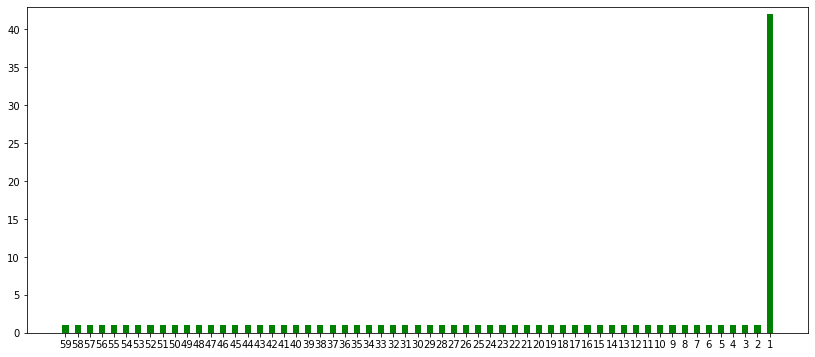

```python
import matplotlib.pyplot as plt
diccionario = {i:contadorInteraciones.count(i) for i in contadorInteraciones}

X = np.arange(len(diccionario))

plt.figure(figsize=(14,6))
plt.bar(X, diccionario.values(), align='center', width=0.5, color='g')
plt.xticks(X, diccionario.keys())
ymax = max(diccionario.values()) + 1
plt.ylim(0, ymax)
plt.show()
```

## Método de Congruencias Lineales.

```python
import numpy as np
import time


rango = int((input("Ingrese la cantidad de numeros pseudoaleatorios:  ")))

a = 5
b = 3
m = 16

cont = 0
lista = []
contInterac = []

for n in range(rango):
    semilla = int(time.time())

    print("semilla",semilla,"iteracion",n)
    cont = 0
    while(True):

        xn = (a * semilla + b) % m
        semilla = xn
        div = semilla / m

        #print(cont,'\t\t',semilla,'\t',"{0:.4f}".format(div),(semilla in lista) is True)

        if((div in lista) is True):

            contInterac.append(cont)

            break

        cont = cont+1
        lista.append(div)

    lista = []
```

```
Ingrese la cantidad de numeros pseudoaleatorios:  100
semilla 1595475941 iteracion 0
semilla 1595475941 iteracion 1
semilla 1595475941 iteracion 2
semilla 1595475941 iteracion 3
semilla 1595475941 iteracion 4
semilla 1595475941 iteracion 5
semilla 1595475941 iteracion 6
semilla 1595475941 iteracion 7
semilla 1595475941 iteracion 8
semilla 1595475941 iteracion 9
semilla 1595475941 iteracion 10
semilla 1595475941 iteracion 11
semilla 1595475941 iteracion 12
semilla 1595475941 iteracion 13
semilla 1595475941 iteracion 14
semilla 1595475941 iteracion 15
semilla 1595475941 iteracion 16
semilla 1595475941 iteracion 17
semilla 1595475941 iteracion 18
semilla 1595475941 iteracion 19
semilla 1595475941 iteracion 20
semilla 1595475941 iteracion 21
semilla 1595475941 iteracion 22
semilla 1595475941 iteracion 23
semilla 1595475941 iteracion 24
semilla 1595475941 iteracion 25
semilla 1595475941 iteracion 26
semilla 1595475941 iteracion 27
semilla 1595475941 iteracion 28
semilla 1595475941 iteracion 29
semilla 1595475941 iteracion 30
semilla 1595475941 iteracion 31
semilla 1595475941 iteracion 32
semilla 1595475941 iteracion 33
semilla 1595475941 iteracion 34
semilla 1595475941 iteracion 35
semilla 1595475941 iteracion 36
semilla 1595475941 iteracion 37
semilla 1595475941 iteracion 38
```

[output cut: 46 more lines]

```
semilla 1595475941 iteracion 85
semilla 1595475941 iteracion 86
semilla 1595475941 iteracion 87
semilla 1595475941 iteracion 88
semilla 1595475941 iteracion 89
semilla 1595475941 iteracion 90
semilla 1595475941 iteracion 91
semilla 1595475941 iteracion 92
semilla 1595475941 iteracion 93
semilla 1595475941 iteracion 94
semilla 1595475941 iteracion 95
semilla 1595475941 iteracion 96
semilla 1595475941 iteracion 97
semilla 1595475941 iteracion 98
semilla 1595475941 iteracion 99
```

### Grafica

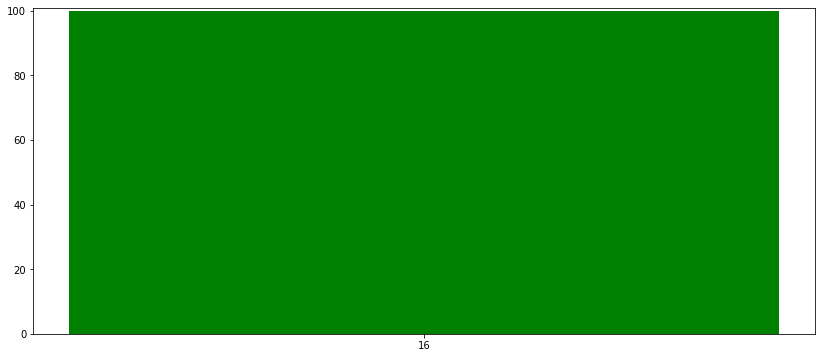

```python
import matplotlib.pyplot as plt

dic = {i:contInterac.count(i) for i in contInterac}



X = np.arange(len(dic))

plt.figure(figsize=(14,6))
plt.bar(X, dic.values(), align='center', width=0.5, color='g')
plt.xticks(X, dic.keys())
ymax = max(dic.values()) + 1
plt.ylim(0, ymax)
plt.show()
```

## Agregar sus conclusiones, opiniones y recomendaciones

En conclucion se puede determinar gracias a las graficas que el metodo de cuadrados medios es un metodo luego de cumplir un ciclo de generacion de numeros se empieza completar con ceros de ai el porque el histograma nos muestra que los un valor de suma alto ya que suma la repeticion de los numeros ceros que rellenan los numeros aleatorios. En el metodo de congruencias liniales podemos observar gracias a la grafica determinar una objecion comun a todos los generadores de numeros pseudo-aleatorios, es que la sucesion de los valores **xn** no es en absoluto aleatoria. Sin embargo, posteriormente veremos que si elegimos las parametros iniciales convenientemente, la sucesion puede asemejarse a una sucesion de n´umeros aleatorios, es por eso que, para mi ejercicio se apreciar que no es un generador adecuado y para poder obter un numero adecuado es necesario aplicar algunos teoremas que nos ayudana obtener y determinar los valores adecuados para una mejor obtencion de numeros pseudo-aleatorios con este metodo.

Se recomienda considerar que los numeros semilla seleccionados para estos metodos no son del todo adecuados ya que para poder saber que numeros o q semillas son las adecuadas es necesario realizar otras operaciones y un poco de investigacion adicional.